# Systems and Policies That Continue to Fail People of Color: Incarceration Edition

## Growth of Prison Population by State

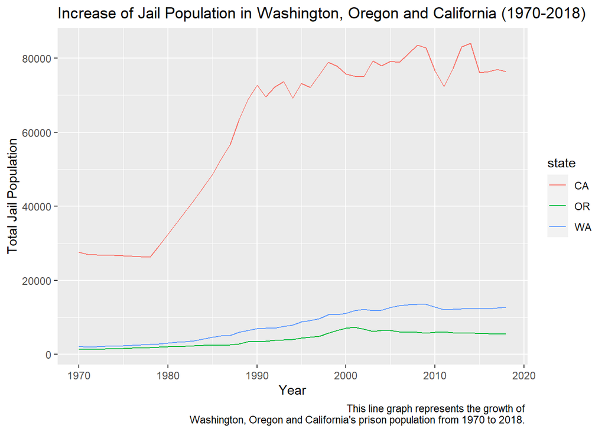

Another question that people may have would be “how has specific state’s prisons changed throughout the years?” When looking closely at Washington, Oregon and California, we notice that California’s incarceration rate increased at a tremendously high rate between 1975 and the year 2000. Since year 2000, the number of people incarcerated in California have steadily stayed at a high number. I wanted to show California because it had one of the highest rates of incarceration people in general, and for people of color. We can further look at California’s laws and how it may unfairly punish the BIPOC community. For Oregon and Washington, the incarcerations has only been slowly increasing. I showed Oregon and Washington because they are cities that many students at the University of Washington are familiar. I also wanted to show how the incarceration could perhaps be different for people of color living in these states due to some of the laws in place for Washington or Oregon.

## Incarceration in Different Counties for Black Americans

[figure not shown]

## Highest rates of incarceration for Black Americans

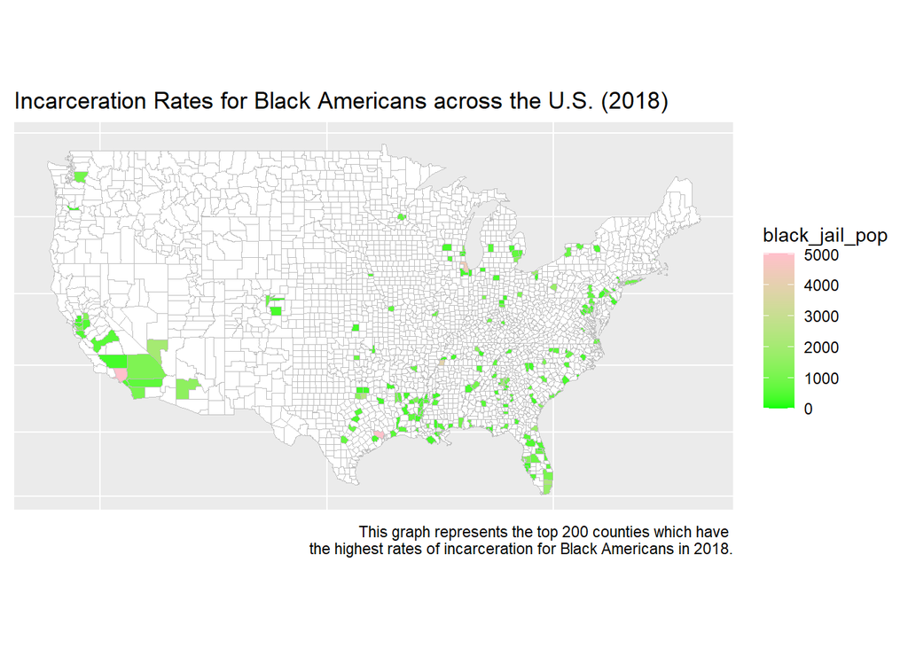